# bdots

```r
library(data.table)
library(bdots)
```

## Overview

This vignette walks through the use of the bdots package for analyzing the bootstrapped differences of time series data. The general workflow will follow three steps:

1. **Curve Fitting**

   During this step, we define the type of curve that will be used to fit our data along with variables to be used in the analysis
2. **Curve Refitting**

   Often, some of the curves returned from the first step have room for improvement. This step allows the user to either quickly attempting refitting a subset of the curves from step one or to manually make adjustments themselves
3. **Bootstrap**

   Having an adequate collection of curves, this function determines the bootstrapped difference, along with computing an adjusted alpha to account for AR1 correlation

This process is represented with three main functions, `bfit -> brefit -> bboot`

This package is under active development. The most recent version can be installed with `devtools::install_github("collinn/bdots")`.

## Fitting Step

For our example, we are going to be using eye tracking data from normal hearing individuals and those with cochlear implants using data from the Visual Word Paradigm (VWP).

```r
head(cohort_unrelated)
```

```
#>    Subject  Time DB_cond  Fixations LookType Group
#>      <num> <int>   <int>      <num>   <fctr> <int>
#> 1:       1     0      50 0.01136364   Cohort    50
#> 2:       1     4      50 0.01136364   Cohort    50
#> 3:       1     8      50 0.01136364   Cohort    50
#> 4:       1    12      50 0.01136364   Cohort    50
#> 5:       1    16      50 0.02272727   Cohort    50
#> 6:       1    20      50 0.02272727   Cohort    50
```

The `bfit` function will create a curve for each unique permutation of `subject`/`group` variables. Here, we will let `LookType` and `DB_cond` be our grouping variables, though we may include as many as we wish (or only a single group assuming that it has multiple values). See `?bfit` for argument information.

```r
fit <- bfit(data = cohort_unrelated,
            subject = "Subject",
            time = "Time",
            y = "Fixations",
            group = c("DB_cond", "LookType"),
            curveFun = doubleGauss(concave = TRUE),
            cores = 2)
```

A key thing to note here is the argument for `curveType` is passed as a function call with arguments that further specify the curve. Currently within the `bdots` package, the available curves are `doubleGauss(concave = TRUE/FALSE),` `logistic()` (no arguments), and `polynomial(degree = n)`. While more curves will be added going forward, users can also specify their own curves, as shown here.

The `bfit` function returns an object of class `bdotsObj`, which inherits from `data.table.` As such, this object can be manipulated and explored with standard `data.table` syntax. In addition to the subject and the grouping columns, we also have a `fit` column, containing the fit from the `gnls` package, a value for `R2`, a boolean indicating `AR1` status, and a final column for `fitCode.` The fit code is a numeric quantity representing the quality of the fit as such:

| fitCode | AR1 | R2 |
| --- | --- | --- |
| 0 | TRUE | R2 > 0.95 |
| 1 | TRUE | 0.8 < R2 < 0.95 |
| 2 | TRUE | R2 < 0.8 |
| 3 | FALSE | R2 > 0.95 |
| 4 | FALSE | 0.8 < R2 < 0.95 |
| 5 | FALSE | R2 < 0.8 |
| 6 | NA | NA |

A `fitCode` of 6 indicates that a fit was not able to be made.

In addition to `plot` and `summary` functions, we also have a method to return a matrix of coefficients from the model fits. Because of the `data.table` syntax, we can examine subsets of this object as well

```r
head(coef(fit))
```

```
#>            mu        ht     sig1     sig2       base1      base2
#> [1,] 417.6899 0.1986711 145.5628 323.1882  0.01586359 0.03412371
#> [2,] 636.8447 0.2632815 306.2330 214.9787 -0.02154793 0.02858644
#> [3,] 647.5295 0.2547779 496.6745 256.4257 -0.18223561 0.01217570
#> [4,] 734.1526 0.2585742 405.6348 240.2926 -0.05751246 0.03455280
#> [5,] 501.1949 0.2258572 398.7760 158.6752 -0.16159477 0.02529158
#> [6,] 460.7152 0.3067659 382.7322 166.0833 -0.24330874 0.03992168
```

```r
head(coef(fit[DB_cond == 50, ]))
```

```
#>            mu        ht     sig1     sig2       base1      base2
#> [1,] 417.6899 0.1986711 145.5628 323.1882  0.01586359 0.03412371
#> [2,] 647.5295 0.2547779 496.6745 256.4257 -0.18223561 0.01217570
#> [3,] 501.1949 0.2258572 398.7760 158.6752 -0.16159477 0.02529158
#> [4,] 524.7172 0.2479396 287.9935 207.0812 -0.05806978 0.10493565
#> [5,] 549.6930 0.2273107 204.0645 229.6397 -0.01001132 0.02878627
#> [6,] 584.5835 0.1594028 226.3004 420.4861  0.01182188 0.00692017
```

The plots for this object will compare the observed data with the fitted curve. Here is an example of the first four:

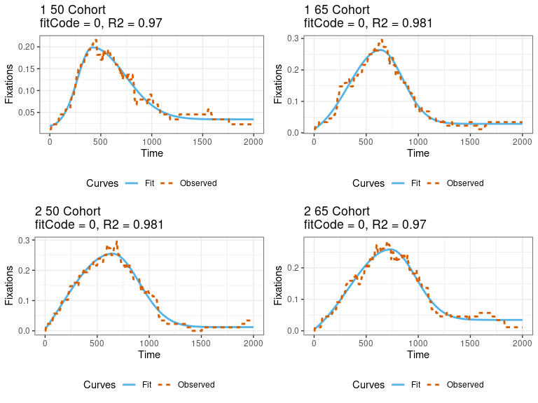

```r
plot(fit[1:4, ])
```

## Refitting Step

Depending on the curve type and the nature of the data, we might find that a collection of our fits aren’t very good, which may impact the quality of the bootstrapping step. Using the `brefit` function, users have the option to either quickly attempt to automatically refit specified curves or to manually review each one and offer alternative starting parameters. The `fitCode` argument provides a lower bound for the fit codes to attempt refitting. The default is `fitCode = 1`, indicating that we wish to attempt refitting all curves that did not have `fitCode == 0`. The object returned is the same as that returned by `bfit`.

```r
## Quickly auto-refit (not run)
refit <- brefit(fit, fitCode = 1L, quickRefit = TRUE)

## Manual refit (not run)
refit <- brefit(fit, fitCode = 1L)
```

For whatever reason, there are some data will will not submit nicely to a curve of the specfied type. One can quickly remove all observations with a fit code equal to or greater than the one provided in `bdRemove`

```r
table(fit$fitCode)
```

```
#>
#>  0  1  2
#> 20 14  2
```

```r
## Remove all failed curve fits
refit <- bdRemove(fit, fitCode = 6L)

table(refit$fitCode)
```

```
#>
#>  0  1  2
#> 20 14  2
```

There is an additional option, `removePairs` which is `TRUE` by default. This indicates that if an observation is removed, all observations for the same subject should also be removed, regardless of fit. This ensures that all subjects have their corresponding pairs in the bootstrapping function for the use of the paired t-test. If the data are not paired, this can be set to `FALSE`.

## Bootstrap

The final step is the bootstrapping process, performed with `bboot`. First, let’s examine the set of curves that we have available from the first step

1. **Difference of Curves**

   Here, we are interested specifically in the difference between two fitted curves. For our example case here, this may be the difference between curves for `DB_cond == 50` and `DB_cond == 65` nested within either the `Cohort` or `Unrelated_Cohort` `LookTypes` (but not both).
2. **Difference of Difference Curves**

   In this case, we are considering the difference of two difference curves similar to the one found above. For example, we may denote the difference between `DB_cond` `50` and `65` within the `Corhort` group as $\text{diff}_{\text{Cohort}}$ and the differences between `DB_cond` `50` and `65` within `Unrelated_Corhort` as $\text{diff}_{\text{UnrelatedCohort}}$. The difference of difference function will then return an analysis of $\text{diff}_{\text{Cohort}}$ - $\text{diff}_{\text{UnrelatedCohort}}$

We can express the type of curve that we wish to fit with a modified formula syntax. It’s helpful to read as “the difference of LHS between elements of RHS”

For the first type, we have

```r
## Only one grouping variable in dataset, take bootstrapped difference
Outcome ~ Group1(value1, value2)

## More than one grouping variable in difference, must specify unique value
Outcome ~ Group1(value1, value2) + Group2(value3)
```

That is, we might read this as “difference of Outcome for value1 and value2 within Group1.”

With our working example, we would find the difference of `DB_cond == 50` and `DB_cond == 65` within `LookType == "Cohort"` with

```r
## Must add LookType(Cohort) to specify
Fixations ~ DB_cond(50, 65) + LookType(Cohort)
```

For this second type of curve, we specify an “inner difference” to be the difference of groups for which we are taking the difference of. The syntax for this case uses a `diffs` function in the formula:

```r
## Difference of difference. Here, outer difference is Group1, inner is Group2
diffs(Outcome, Group2(value3, value4)) ~ Group1(value1, value2)

## Same as above if three or more grouping variables
diffs(Outcome, Group2(value3, value4)) ~ Group1(value1, value2) + Group3(value5)
```

For the example illustrated in (2) above, the difference $\text{diff}_{50} - \text{diff}_{65}$ represents our inner difference, each nested within one of the values for `LookType.` The “outer difference” is then difference of these between `LookTypes`. The syntax here would be

```r
diffs(Fixations, DB_cond(50, 65)) ~ LookType(Cohort, Unrelated_Cohort)
```

Here, we show a fit for each

```r
boot1 <- bboot(formula = Fixation ~ DB_cond(50, 65) + LookType(Cohort),
               bdObj = refit,
               Niter = 1000,
               alpha = 0.05,
               padj = "oleson",
               cores = 2)

boot2 <- bboot(formula = diffs(Fixation, LookType(Cohort, Unrelated_Cohort)) ~ DB_cond(50, 65),
               bdObj = refit,
               Niter = 1000,
               alpha = 0.05,
               padj = "oleson",
               cores = 2)
```

For each, we can then produce a model summary, as well as a plot of difference curves

```r
summary(boot1)
```

```
#>
#> bdotsBoot Summary
#>
#> Curve Function: doubleGauss
#> Formula: Fixations ~ (Time < mu) * (exp(-1 * (Time - mu)^2/(2 * sig1^2)) * (ht - base1) + base1) + (mu <= Time) * (exp(-1 * (Time - mu)^2/(2 * sig2^2)) * (ht - base2) + base2)
#> Time Range: (0, 2000) [501 points]
#>
#> Difference of difference: FALSE
#> Paired t-test: TRUE
#> Difference: DB_cond -- 50 65
#>
#> Autocorrelation Estimate:
#> FWER adjust method: oleson
#> Alpha: 0.05
#> Adjusted alpha:
#> Significant Intervals:
#> NULL
```

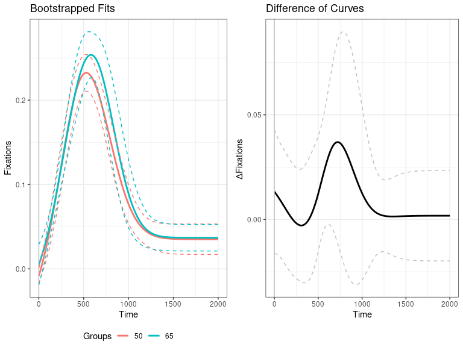

```r
plot(boot1)
```